# Приоритизация гипотез и анализ А/В теста

# Содержание

## Описание проекта

В данном проекте:

1. произведена приоритизация гипотез по увеличению выручки крупного интернет-магазина
2. проведён анализ А/В-теста

**Основные задачи**:

- выявить наиболее перспективные гипотезы по увеличению выручки при помощи фреймворков ICE и RICE
- проанализировать результаты А/В-теста, принять решение и объяснить его

**План работы**:

1. Приоритизация гипотез:
- при помощи фреймворка ICE
- при помощи фреймворка RICE
- сравнение и объяснение различий
1. Анализ А/В-теста:
- анализ метрик (выручка, средний чек, кол-во заказов)
- расчёт перцентилей, определение аномалий
- расчёт статистической значимости различий по "сырым" и "очищенным" данным
- обоснование решения по результатам теста

**Описание данных**:

В исследовании используются данные о гипотезах, составленных отделом маркетинга компании, а также данные о заказах и посетителях, которые стали частью А/В-теста.

## Открытие данных

Импортируем необходимые библиотеки:

```python
import pandas as pd
import os
import numpy as np
import math as mth
from scipy import stats as st
import datetime as dt
from matplotlib import pyplot as plt
import seaborn as sns
```

Открываем файлы:

```python
if os.path.exists('/datasets/hypothesis.csv'):
    hypothesis = pd.read_csv('/datasets/hypothesis.csv')
else:
    hypothesis = pd.read_csv('/C:/datasets/hypothesis.csv')
```

```python
if os.path.exists('/datasets/orders.csv'):
    orders = pd.read_csv('/datasets/orders.csv')
else:
    orders = pd.read_csv('/C:/datasets/orders.csv')
```

```python
if os.path.exists('/datasets/visitors.csv'):
    visitors = pd.read_csv('/datasets/visitors.csv')
else:
    visitors = pd.read_csv('/C:/datasets/visitors.csv')
```

Для ознакомления и проверки данных будем использовать собственную функцию:

```python
def my_check_function (dataset):
    '''Функция для ознакомления и проверки даных'''
    print('Как выглядят случайные 5 строк:')
    display(dataset.sample(5, random_state=42))
    print()
    print('Общая информация о данных, наименования столбцов, типы данных:')
    print(dataset.info())
    print()
    print('Есть ли пропуски, сколько их:')
    print(dataset.isna().sum())
    print('Доля пропущенных значений:')
    print(dataset.isna().mean())
    print()
    print('Есть ли явные дубликаты, сколько их:')
    print(dataset.duplicated().sum())
    print('Доля явных дубликатов:')
    print(dataset.duplicated().mean())
    print()
    print('Подробное описание данных:')
    display(dataset.describe())
```

```python
my_check_function(hypothesis)
```

```
Как выглядят случайные 5 строк:
```

|  | Hypothesis | Reach | Impact | Confidence | Efforts |
| --- | --- | --- | --- | --- | --- |
| 7 | Добавить форму подписки на все основные страни... | 10 | 7 | 8 | 5 |
| 1 | Запустить собственную службу доставки, что сок... | 2 | 5 | 4 | 10 |
| 5 | Добавить страницу отзывов клиентов о магазине,... | 3 | 2 | 2 | 3 |
| 0 | Добавить два новых канала привлечения трафика,... | 3 | 10 | 8 | 6 |
| 8 | Запустить акцию, дающую скидку на товар в день... | 1 | 9 | 9 | 5 |

```
Общая информация о данных, наименования столбцов, типы данных:
<class 'pandas.core.frame.DataFrame'>
RangeIndex: 9 entries, 0 to 8
Data columns (total 5 columns):
 #   Column      Non-Null Count  Dtype
---  ------      --------------  -----
 0   Hypothesis  9 non-null      object
 1   Reach       9 non-null      int64
 2   Impact      9 non-null      int64
 3   Confidence  9 non-null      int64
 4   Efforts     9 non-null      int64
dtypes: int64(4), object(1)
memory usage: 488.0+ bytes
None

Есть ли пропуски, сколько их:
Hypothesis    0
Reach         0
Impact        0
Confidence    0
Efforts       0
dtype: int64
Доля пропущенных значений:
Hypothesis    0.0
Reach         0.0
Impact        0.0
Confidence    0.0
Efforts       0.0
dtype: float64

Есть ли явные дубликаты, сколько их:
0
Доля явных дубликатов:
0.0

Подробное описание данных:
```

|  | Reach | Impact | Confidence | Efforts |
| --- | --- | --- | --- | --- |
| count | 9.000000 | 9.000000 | 9.000000 | 9.000000 |
| mean | 4.777778 | 4.777778 | 5.555556 | 4.888889 |
| std | 3.153481 | 3.192874 | 3.045944 | 2.803767 |
| min | 1.000000 | 1.000000 | 1.000000 | 1.000000 |
| 25% | 3.000000 | 3.000000 | 3.000000 | 3.000000 |
| 50% | 3.000000 | 3.000000 | 7.000000 | 5.000000 |
| 75% | 8.000000 | 7.000000 | 8.000000 | 6.000000 |
| max | 10.000000 | 10.000000 | 9.000000 | 10.000000 |

```python
my_check_function(orders)
```

```
Как выглядят случайные 5 строк:
```

|  | transactionId | visitorId | date | revenue | group |
| --- | --- | --- | --- | --- | --- |
| 921 | 3102219893 | 151496413 | 2019-08-21 | 350 | A |
| 321 | 1775445570 | 3118528100 | 2019-08-19 | 1090 | A |
| 101 | 3847160695 | 1830791924 | 2019-08-01 | 2350 | A |
| 920 | 3057892078 | 249864742 | 2019-08-21 | 5530 | B |
| 58 | 2145193898 | 1221478247 | 2019-08-16 | 1440 | B |

```
Общая информация о данных, наименования столбцов, типы данных:
<class 'pandas.core.frame.DataFrame'>
RangeIndex: 1197 entries, 0 to 1196
Data columns (total 5 columns):
 #   Column         Non-Null Count  Dtype
---  ------         --------------  -----
 0   transactionId  1197 non-null   int64
 1   visitorId      1197 non-null   int64
 2   date           1197 non-null   object
 3   revenue        1197 non-null   int64
 4   group          1197 non-null   object
dtypes: int64(3), object(2)
memory usage: 46.9+ KB
None

Есть ли пропуски, сколько их:
transactionId    0
visitorId        0
date             0
revenue          0
group            0
dtype: int64
Доля пропущенных значений:
transactionId    0.0
visitorId        0.0
date             0.0
revenue          0.0
group            0.0
dtype: float64

Есть ли явные дубликаты, сколько их:
0
Доля явных дубликатов:
0.0

Подробное описание данных:
```

|  | transactionId | visitorId | revenue |
| --- | --- | --- | --- |
| count | 1.197000e+03 | 1.197000e+03 | 1.197000e+03 |
| mean | 2.155621e+09 | 2.165960e+09 | 8.348006e+03 |
| std | 1.229085e+09 | 1.236014e+09 | 3.919113e+04 |
| min | 1.062393e+06 | 5.114589e+06 | 5.000000e+01 |
| 25% | 1.166776e+09 | 1.111826e+09 | 1.220000e+03 |
| 50% | 2.145194e+09 | 2.217985e+09 | 2.978000e+03 |
| 75% | 3.237740e+09 | 3.177606e+09 | 8.290000e+03 |
| max | 4.293856e+09 | 4.283872e+09 | 1.294500e+06 |

```python
my_check_function(visitors)
```

```
Как выглядят случайные 5 строк:
```

|  | date | group | visitors |
| --- | --- | --- | --- |
| 50 | 2019-08-20 | B | 560 |
| 56 | 2019-08-26 | B | 676 |
| 0 | 2019-08-01 | A | 719 |
| 57 | 2019-08-27 | B | 720 |
| 5 | 2019-08-06 | A | 667 |

```
Общая информация о данных, наименования столбцов, типы данных:
<class 'pandas.core.frame.DataFrame'>
RangeIndex: 62 entries, 0 to 61
Data columns (total 3 columns):
 #   Column    Non-Null Count  Dtype
---  ------    --------------  -----
 0   date      62 non-null     object
 1   group     62 non-null     object
 2   visitors  62 non-null     int64
dtypes: int64(1), object(2)
memory usage: 1.6+ KB
None

Есть ли пропуски, сколько их:
date        0
group       0
visitors    0
dtype: int64
Доля пропущенных значений:
date        0.0
group       0.0
visitors    0.0
dtype: float64

Есть ли явные дубликаты, сколько их:
0
Доля явных дубликатов:
0.0

Подробное описание данных:
```

|  | visitors |
| --- | --- |
| count | 62.000000 |
| mean | 607.290323 |
| std | 114.400560 |
| min | 361.000000 |
| 25% | 534.000000 |
| 50% | 624.500000 |
| 75% | 710.500000 |
| max | 770.000000 |

### Вывод

На первый взгляд проблем в данных нет, для дальнейшей работы необходимо только преобразовать формат данных, связанных со временем - это столбцы 'date' в таблицах orders и visitors.

## Предобработка данных

```python
orders['date'] = pd.to_datetime(orders['date'], format='%Y-%m-%d')
```

```python
visitors['date'] = pd.to_datetime(visitors['date'], format='%Y-%m-%d')
```

Можно ещё проверить данные на скрытые дубликаты. Например, есть ли у нас дубликаты идентификаторов заказов:

```python
orders['transactionId'].duplicated().sum()
```

```
0
```

Итак, у нас нет дубликатов в идентификаторах заказов, но, возможно, есть скрытые дубликаты среди других столбцов. Например, было бы странно, если один и тот же покупатель в одну и ту же дату делал бы покупку на одну и ту же сумму:

```python
orders[orders.duplicated(subset=['visitorId', 'date','revenue'], keep=False)]
```

|  | transactionId | visitorId | date | revenue | group |
| --- | --- | --- | --- | --- | --- |
| 556 | 571224785 | 3941503500 | 2019-08-06 | 4990 | B |
| 558 | 3621273697 | 3941503500 | 2019-08-06 | 4990 | B |
| 662 | 1811671147 | 4266935830 | 2019-08-29 | 78990 | A |
| 682 | 1216533772 | 4266935830 | 2019-08-29 | 78990 | B |
| 970 | 3478707774 | 2587333274 | 2019-08-08 | 3600 | A |
| 972 | 2419539947 | 2587333274 | 2019-08-08 | 3600 | B |

Действительно, странные случаи есть, причём самое важное здесь для нас - что такие случаи дублируются в разные группы теста! Это явно ненормально и дальнейшем это помешает объективному анализу результатов теста.

Проверим корректность разбиения пользователей на группы.

Создадим датафрейм с парами значений 'visitorId' и 'group', удалим в нём явные дубликаты:

```python
visitorsGroups = orders[['visitorId', 'group']].drop_duplicates()
visitorsGroups.sort_values(by=['visitorId','group'])
```

|  | visitorId | group |
| --- | --- | --- |
| 56 | 5114589 | B |
| 573 | 6958315 | B |
| 703 | 8300375 | A |
| 71 | 8300375 | B |
| 233 | 11685486 | A |
| ... | ... | ... |
| 682 | 4266935830 | B |
| 886 | 4278982564 | A |
| 576 | 4279090005 | B |
| 392 | 4281247801 | B |
| 974 | 4283872382 | B |

1089 rows × 2 columns

Мы уже знаем, что в данных есть пользователи, которые попали в обе группы сразу. Теперь посчитаем, сколько подобных случаев:

```python
visitorsGroups['visitorId'].duplicated().sum()
```

```
58
```

У нас 58 случаев, когда один и тот же пользователь попал и в группу А, и в группу В. Выделим этих пользователей:

```python
visitorsDuplicated = (visitorsGroups[visitorsGroups['visitorId'].duplicated(keep=False)]
                                                                .sort_values(by=['visitorId', 'group']))
visitorsDuplicated = visitorsDuplicated['visitorId'].drop_duplicates()
len(visitorsDuplicated)
```

```
58
```

Посмотрим, сколько у нас останется данных без этих пользователей:

```python
orders_new = orders[np.logical_not(orders['visitorId'].isin(visitorsDuplicated))]
len(orders_new)
```

```
1016
```

Посчитаем, какой процент данных составляют данные с "продублированными" пользователями от общего объёма данных:

```python
(len(orders) - len(orders_new)) / len(orders) *100
```

```
15.121136173767752
```

Многовато, но ради корректного анализа результатов А/В-теста придётся их удалить. Перепишем переменные:

```python
orders_raw = orders
orders = orders_new
```

### Вывод

В результате предобработки данных:

- был изменён формат данных, связанных со временем
- были обнаружены скрытые дубликаты среди данных о пользователях: 58 пользователей попали и в группу А, и в группу В
- данные в таблице orders о таких пользователях не будут браться в работу при статистических тестах и анализе А/В-теста

## Приоритизация гипотез

Сделаем настройку, чтобы посмотреть текст столбца целиком:

```python
pd.set_option('display.max_colwidth', None)
```

Посмотрим на гипотезы:

```python
hypothesis
```

|  | Hypothesis | Reach | Impact | Confidence | Efforts |
| --- | --- | --- | --- | --- | --- |
| 0 | Добавить два новых канала привлечения трафика, что позволит привлекать на 30% больше пользователей | 3 | 10 | 8 | 6 |
| 1 | Запустить собственную службу доставки, что сократит срок доставки заказов | 2 | 5 | 4 | 10 |
| 2 | Добавить блоки рекомендаций товаров на сайт интернет магазина, чтобы повысить конверсию и средний чек заказа | 8 | 3 | 7 | 3 |
| 3 | Изменить структура категорий, что увеличит конверсию, т.к. пользователи быстрее найдут нужный товар | 8 | 3 | 3 | 8 |
| 4 | Изменить цвет фона главной страницы, чтобы увеличить вовлеченность пользователей | 3 | 1 | 1 | 1 |
| 5 | Добавить страницу отзывов клиентов о магазине, что позволит увеличить количество заказов | 3 | 2 | 2 | 3 |
| 6 | Показать на главной странице баннеры с актуальными акциями и распродажами, чтобы увеличить конверсию | 5 | 3 | 8 | 3 |
| 7 | Добавить форму подписки на все основные страницы, чтобы собрать базу клиентов для email-рассылок | 10 | 7 | 8 | 5 |
| 8 | Запустить акцию, дающую скидку на товар в день рождения | 1 | 9 | 9 | 5 |

Как мы видим, для всех гипотез уже расставлены баллы по показателям, необходимым для применения фреймворков. Нам остаётся только сделать расчёты и отсортировать список по убыванию оценок, чтобы выявить приоритетные гипотезы.

Для удобства добавим каждой гипотезе её порядковый номер:

```python
hypothesis.insert(1, 'Hyp_number', list(range(1, 10)))
```

```python
hypothesis['Hyp_number'] = hypothesis['Hyp_number'].apply(lambda x: f'number_{x}')
```

```python
hypothesis
```

|  | Hypothesis | Hyp_number | Reach | Impact | Confidence | Efforts |
| --- | --- | --- | --- | --- | --- | --- |
| 0 | Добавить два новых канала привлечения трафика, что позволит привлекать на 30% больше пользователей | number_1 | 3 | 10 | 8 | 6 |
| 1 | Запустить собственную службу доставки, что сократит срок доставки заказов | number_2 | 2 | 5 | 4 | 10 |
| 2 | Добавить блоки рекомендаций товаров на сайт интернет магазина, чтобы повысить конверсию и средний чек заказа | number_3 | 8 | 3 | 7 | 3 |
| 3 | Изменить структура категорий, что увеличит конверсию, т.к. пользователи быстрее найдут нужный товар | number_4 | 8 | 3 | 3 | 8 |
| 4 | Изменить цвет фона главной страницы, чтобы увеличить вовлеченность пользователей | number_5 | 3 | 1 | 1 | 1 |
| 5 | Добавить страницу отзывов клиентов о магазине, что позволит увеличить количество заказов | number_6 | 3 | 2 | 2 | 3 |
| 6 | Показать на главной странице баннеры с актуальными акциями и распродажами, чтобы увеличить конверсию | number_7 | 5 | 3 | 8 | 3 |
| 7 | Добавить форму подписки на все основные страницы, чтобы собрать базу клиентов для email-рассылок | number_8 | 10 | 7 | 8 | 5 |
| 8 | Запустить акцию, дающую скидку на товар в день рождения | number_9 | 1 | 9 | 9 | 5 |

### фреймворк ICE

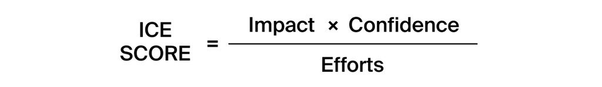

```python
hypothesis['ICE'] = hypothesis['Impact'] * hypothesis['Confidence'] / hypothesis['Efforts']
```

```python
hypothesis = hypothesis.sort_values(by='ICE', ascending=False)
hypothesis['ICE_score'] = list(range(1, 10))
hypothesis
```

|  | Hypothesis | Hyp_number | Reach | Impact | Confidence | Efforts | ICE | ICE_score |
| --- | --- | --- | --- | --- | --- | --- | --- | --- |
| 8 | Запустить акцию, дающую скидку на товар в день рождения | number_9 | 1 | 9 | 9 | 5 | 16.200000 | 1 |
| 0 | Добавить два новых канала привлечения трафика, что позволит привлекать на 30% больше пользователей | number_1 | 3 | 10 | 8 | 6 | 13.333333 | 2 |
| 7 | Добавить форму подписки на все основные страницы, чтобы собрать базу клиентов для email-рассылок | number_8 | 10 | 7 | 8 | 5 | 11.200000 | 3 |
| 6 | Показать на главной странице баннеры с актуальными акциями и распродажами, чтобы увеличить конверсию | number_7 | 5 | 3 | 8 | 3 | 8.000000 | 4 |
| 2 | Добавить блоки рекомендаций товаров на сайт интернет магазина, чтобы повысить конверсию и средний чек заказа | number_3 | 8 | 3 | 7 | 3 | 7.000000 | 5 |
| 1 | Запустить собственную службу доставки, что сократит срок доставки заказов | number_2 | 2 | 5 | 4 | 10 | 2.000000 | 6 |
| 5 | Добавить страницу отзывов клиентов о магазине, что позволит увеличить количество заказов | number_6 | 3 | 2 | 2 | 3 | 1.333333 | 7 |
| 3 | Изменить структура категорий, что увеличит конверсию, т.к. пользователи быстрее найдут нужный товар | number_4 | 8 | 3 | 3 | 8 | 1.125000 | 8 |
| 4 | Изменить цвет фона главной страницы, чтобы увеличить вовлеченность пользователей | number_5 | 3 | 1 | 1 | 1 | 1.000000 | 9 |

**Вывод:**

- наиболее высокие оценки получили *гипотезы 9, 1, 8*
- средние оценки получили *гипотезы 7, 3*

### фреймворк RICE

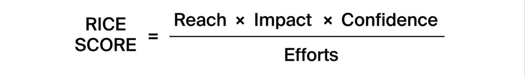

```python
hypothesis['RICE'] = (hypothesis['Reach'] * hypothesis['Impact'] * hypothesis['Confidence']) / hypothesis['Efforts']
```

```python
hypothesis = hypothesis.sort_values(by='RICE', ascending=False)
hypothesis['RICE_score'] = list(range(1, 10))
hypothesis
```

|  | Hypothesis | Hyp_number | Reach | Impact | Confidence | Efforts | ICE | ICE_score | RICE | RICE_score |
| --- | --- | --- | --- | --- | --- | --- | --- | --- | --- | --- |
| 7 | Добавить форму подписки на все основные страницы, чтобы собрать базу клиентов для email-рассылок | number_8 | 10 | 7 | 8 | 5 | 11.200000 | 3 | 112.0 | 1 |
| 2 | Добавить блоки рекомендаций товаров на сайт интернет магазина, чтобы повысить конверсию и средний чек заказа | number_3 | 8 | 3 | 7 | 3 | 7.000000 | 5 | 56.0 | 2 |
| 0 | Добавить два новых канала привлечения трафика, что позволит привлекать на 30% больше пользователей | number_1 | 3 | 10 | 8 | 6 | 13.333333 | 2 | 40.0 | 3 |
| 6 | Показать на главной странице баннеры с актуальными акциями и распродажами, чтобы увеличить конверсию | number_7 | 5 | 3 | 8 | 3 | 8.000000 | 4 | 40.0 | 4 |
| 8 | Запустить акцию, дающую скидку на товар в день рождения | number_9 | 1 | 9 | 9 | 5 | 16.200000 | 1 | 16.2 | 5 |
| 3 | Изменить структура категорий, что увеличит конверсию, т.к. пользователи быстрее найдут нужный товар | number_4 | 8 | 3 | 3 | 8 | 1.125000 | 8 | 9.0 | 6 |
| 1 | Запустить собственную службу доставки, что сократит срок доставки заказов | number_2 | 2 | 5 | 4 | 10 | 2.000000 | 6 | 4.0 | 7 |
| 5 | Добавить страницу отзывов клиентов о магазине, что позволит увеличить количество заказов | number_6 | 3 | 2 | 2 | 3 | 1.333333 | 7 | 4.0 | 8 |
| 4 | Изменить цвет фона главной страницы, чтобы увеличить вовлеченность пользователей | number_5 | 3 | 1 | 1 | 1 | 1.000000 | 9 | 3.0 | 9 |

**Вывод:**

- наиболее высокие оценки получила *гипотеза 8*
- средние оценки получили *гипотезы 3, 1, 7, 9*

### Как и почему изменилась приоритизация гипотез при применении RICE вместо ICE

Как мы видим, приоритизация меняется в зависимости от фреймворка:

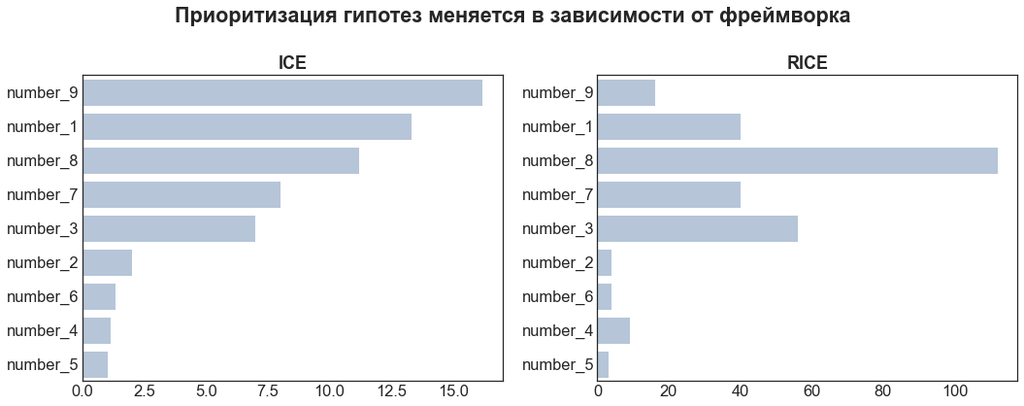

```python
plt.figure(figsize=(15, 6))
sns.set(font_scale=1.5)
plt.style.use('seaborn-white')
plt.suptitle('Приоритизация гипотез меняется в зависимости от фреймворка', fontweight='bold')

hypothesis = hypothesis.sort_values(by='ICE', ascending=False)

ax1 = plt.subplot(1, 2, 1)
sns.barplot(data=hypothesis, x='ICE', y='Hyp_number', color='lightsteelblue')
plt.title('ICE', fontweight='bold')
plt.xlabel('')
plt.ylabel('')

ax2 = plt.subplot(1, 2, 2)
sns.barplot(data=hypothesis, x='RICE', y='Hyp_number', color='lightsteelblue')
plt.title('RICE', fontweight='bold')
plt.xlabel('')
plt.ylabel('')

plt.tight_layout()
plt.show();
```

- значения первых пяти гипотез с лучшими баллами в ICE изменились во фреймворке RICE, например, 9-я гипотеза стала иметь небольшое значение, а 8-я шипотеза вышла на первое место с явным отрывом
- но есть и общий момент: гипотезы с наименьшими баллами в ICE (номера 2, 6, 4, 5) имеют такое же низкое положение в условном рейтинге RICE

Что же влияет на расстановку? Взглянем на формулы:

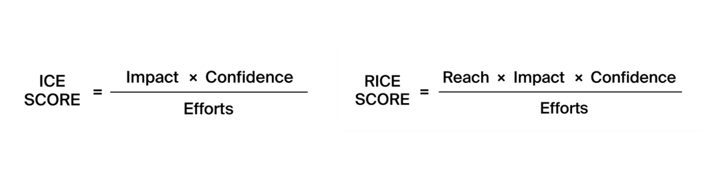

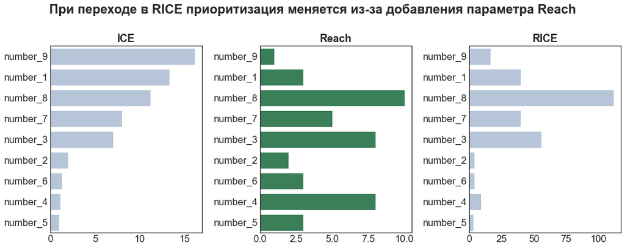

```python
plt.figure(figsize=(15, 6))
sns.set(font_scale=1.5)
plt.style.use('seaborn-white')
plt.suptitle('При переходе в RICE приоритизация меняется из-за добавления параметра Reach', fontweight='bold')

ax1 = plt.subplot(1, 3, 1)
sns.barplot(data=hypothesis, x='ICE', y='Hyp_number', color='lightsteelblue')
plt.title('ICE', fontweight='bold')
plt.xlabel('')
plt.ylabel('')

ax2 = plt.subplot(1, 3, 2)
sns.barplot(data=hypothesis, x='Reach', y='Hyp_number', color='seagreen')
plt.title('Reach', fontweight='bold')
plt.xlabel('')
plt.ylabel('')

ax3 = plt.subplot(1, 3, 3)
sns.barplot(data=hypothesis, x='RICE', y='Hyp_number', color='lightsteelblue')
plt.title('RICE', fontweight='bold')
plt.xlabel('')
plt.ylabel('')

plt.tight_layout()
plt.show();
```

### Вывод

- при применении фреймворка RICE вместо ICE меняется приоритизация гипотез. Это происходит из-за добавления параметра Reach, то есть охвата пользователей.
- при этом гипотезы, которые в ICE набрали много баллов, при переходе в RICE меняются между собой местами, но остаются на лидирующих позициях. А гипотезы, имеющие низкие баллы в ICE, даже при сильном параметре Reach, не смогли выбраться в топ во фреймворке RICE.

## Анализ А/В-теста

### Подготовка данных

Чтобы проанализировать результаты А/В-теста, нам нужно сначала поработать с данными. Создадим датафрейм с уникальными парами значений 'date' и 'group' из таблицы orders:

```python
datesGroups = orders[['date', 'group']].drop_duplicates()
datesGroups
```

|  | date | group |
| --- | --- | --- |
| 0 | 2019-08-15 | B |
| 7 | 2019-08-15 | A |
| 45 | 2019-08-16 | A |
| 47 | 2019-08-16 | B |
| 55 | 2019-08-01 | A |
| ... | ... | ... |
| 1068 | 2019-08-12 | A |
| 1114 | 2019-08-13 | B |
| 1116 | 2019-08-13 | A |
| 1149 | 2019-08-14 | B |
| 1150 | 2019-08-14 | A |

62 rows × 2 columns

Обработаем данные о заказах. Создадим переменную, где будут следующие данные:

- дата
- группа А/В-теста
- число уникальных заказов в группе теста по указанную дату включительно
- число уникальных пользователей, совершивших хотя бы 1 заказ в группе теста по указанную дату включительно
- суммарная выручка заказов в группе теста по указанную дату включительно

```python
ordersAggregated = (datesGroups
    .apply(lambda x: orders[np.logical_and(orders['date']<=x['date'], orders['group']==x['group'])]
    .agg({'date':'max', 'group':'max', 'transactionId':pd.Series.nunique,
          'visitorId':pd.Series.nunique, 'revenue':'sum'}), axis=1)
    .sort_values(by=['date', 'group']))
ordersAggregated
```

|  | date | group | transactionId | visitorId | revenue |
| --- | --- | --- | --- | --- | --- |
| 55 | 2019-08-01 | A | 23 | 19 | 142779 |
| 66 | 2019-08-01 | B | 17 | 17 | 59758 |
| 175 | 2019-08-02 | A | 42 | 36 | 234381 |
| 173 | 2019-08-02 | B | 40 | 39 | 221801 |
| 291 | 2019-08-03 | A | 66 | 60 | 346854 |
| ... | ... | ... | ... | ... | ... |
| 533 | 2019-08-29 | B | 510 | 490 | 4746610 |
| 757 | 2019-08-30 | A | 460 | 437 | 3311413 |
| 690 | 2019-08-30 | B | 531 | 511 | 4955833 |
| 958 | 2019-08-31 | A | 468 | 445 | 3364656 |
| 930 | 2019-08-31 | B | 548 | 528 | 5068972 |

62 rows × 5 columns

обработаем данные о посетителях. Создадим переменную со следующими данными:

- дата
- группа А/В-теста
- количество уникальных посетителей в группе теста по указанную дату включительно

```python
visitorsAggregated = (datesGroups
    .apply(lambda x: visitors[np.logical_and(visitors['date']<=x['date'], visitors['group']==x['group'])]
    .agg({'date':'max', 'group':'max', 'visitors':'sum'}), axis=1)
    .sort_values(by=['date','group']))
visitorsAggregated
```

|  | date | group | visitors |
| --- | --- | --- | --- |
| 55 | 2019-08-01 | A | 719 |
| 66 | 2019-08-01 | B | 713 |
| 175 | 2019-08-02 | A | 1338 |
| 173 | 2019-08-02 | B | 1294 |
| 291 | 2019-08-03 | A | 1845 |
| ... | ... | ... | ... |
| 533 | 2019-08-29 | B | 17708 |
| 757 | 2019-08-30 | A | 18037 |
| 690 | 2019-08-30 | B | 18198 |
| 958 | 2019-08-31 | A | 18736 |
| 930 | 2019-08-31 | B | 18916 |

62 rows × 3 columns

Объединим обработанные данные в одну переменную:

```python
cumulativeData = ordersAggregated.merge(visitorsAggregated, left_on=['date','group'], right_on=['date','group'])
cumulativeData.columns = ['date','group','orders','buyers','revenue','visitors']
cumulativeData
```

|  | date | group | orders | buyers | revenue | visitors |
| --- | --- | --- | --- | --- | --- | --- |
| 0 | 2019-08-01 | A | 23 | 19 | 142779 | 719 |
| 1 | 2019-08-01 | B | 17 | 17 | 59758 | 713 |
| 2 | 2019-08-02 | A | 42 | 36 | 234381 | 1338 |
| 3 | 2019-08-02 | B | 40 | 39 | 221801 | 1294 |
| 4 | 2019-08-03 | A | 66 | 60 | 346854 | 1845 |
| ... | ... | ... | ... | ... | ... | ... |
| 57 | 2019-08-29 | B | 510 | 490 | 4746610 | 17708 |
| 58 | 2019-08-30 | A | 460 | 437 | 3311413 | 18037 |
| 59 | 2019-08-30 | B | 531 | 511 | 4955833 | 18198 |
| 60 | 2019-08-31 | A | 468 | 445 | 3364656 | 18736 |
| 61 | 2019-08-31 | B | 548 | 528 | 5068972 | 18916 |

62 rows × 6 columns

Выделим отдельно данные по группам теста:

```python
cumulativeRevenueA = cumulativeData[cumulativeData['group']=='A'][['date','revenue','orders']]
cumulativeRevenueB = cumulativeData[cumulativeData['group']=='B'][['date','revenue','orders']]
```

### График кумулятивной выручки по группам. Выводы и предположения.

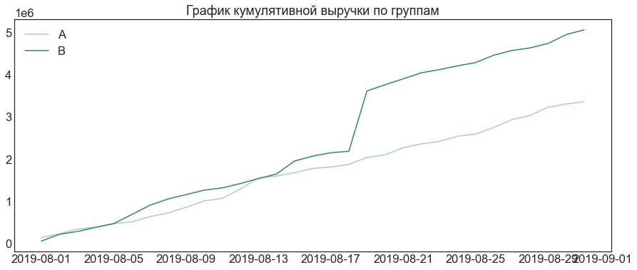

```python
plt.figure(figsize=(15, 6))
sns.set(font_scale=1.5)
plt.style.use('seaborn-white')

plt.plot(cumulativeRevenueA['date'], cumulativeRevenueA['revenue'], label='A', color='lightsteelblue')
plt.plot(cumulativeRevenueB['date'], cumulativeRevenueB['revenue'], label='B', color='seagreen')
plt.legend()
plt.title('График кумулятивной выручки по группам')

plt.show();
```

- выручка более-менее равномерно увеличивается в течение всего теста
- в группе В есть резкий рост в одном месте. Это может быть вызвано всплеском количества заказов, либо появлении очень дорогих заказов

### График кумулятивного среднего чека по группам. Выводы и предположения.

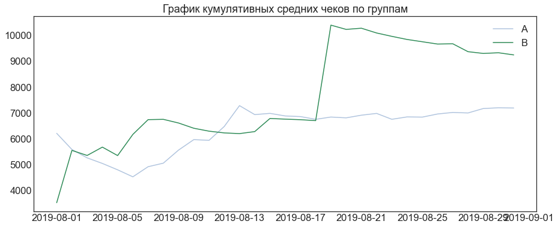

```python
plt.figure(figsize=(15, 6))
sns.set(font_scale=1.5)
plt.style.use('seaborn-white')

plt.plot(cumulativeRevenueA['date'], cumulativeRevenueA['revenue']/cumulativeRevenueA['orders'], label='A',
         color='lightsteelblue')
plt.plot(cumulativeRevenueB['date'], cumulativeRevenueB['revenue']/cumulativeRevenueB['orders'], label='B',
         color='seagreen')
plt.legend()
plt.title('График кумулятивных средних чеков по группам')

plt.show();
```

- для группы А кумулятивный средний чек в первой половине теста вырос и затем зафиксировался на уровне около 7000
- для группы В кумулятивный средний чек резко вырос во второй половине теста до 10000 и постепенно снизился до 9000
- такой резкий всплеск в группе В говорит о влиянии дорогих заказов

### График относительного изменения кумулятивного среднего чека группы B к группе A. Выводы и предположения.

```python
mergedCumulativeRevenue = cumulativeRevenueA.merge(cumulativeRevenueB, left_on='date', right_on='date',
                                                   how='left',suffixes=['A','B'])
```

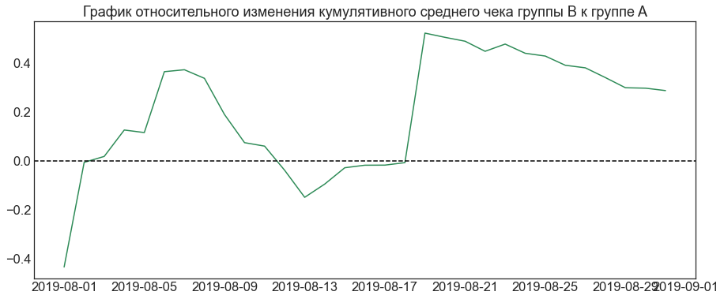

```python
plt.figure(figsize=(15, 6))
sns.set(font_scale=1.5)
plt.style.use('seaborn-white')

plt.plot(mergedCumulativeRevenue['date'],
         (mergedCumulativeRevenue['revenueB']/mergedCumulativeRevenue['ordersB'])/
         (mergedCumulativeRevenue['revenueA']/mergedCumulativeRevenue['ordersA'])-1, color='seagreen')

plt.axhline(y=0, color='black', linestyle='--')
plt.title('График относительного изменения кумулятивного среднего чека группы B к группе A')

plt.show();
```

- различия между группами сильно скачут, похоже, мы видим влияние "выбросов" - необычно крупных/дорогих заказов
- группа В почти всё время выше нуля, и даже постепенное снижение - не катастрофа: в целом группа В показывает хорошие результаты

### График кумулятивного среднего количества заказов на посетителя по группам. Выводы и предположения.

```python
cumulativeData['conversion'] = cumulativeData['orders']/cumulativeData['visitors']
```

```python
cumulativeDataA = cumulativeData[cumulativeData['group']=='A']
cumulativeDataB = cumulativeData[cumulativeData['group']=='B']
```

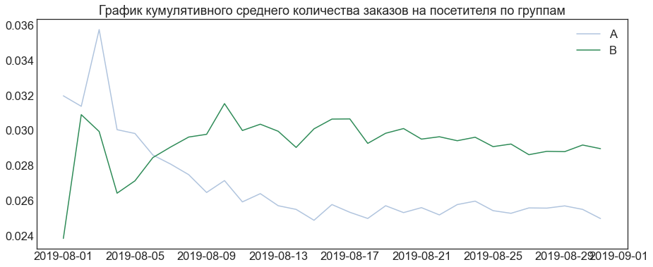

```python
plt.figure(figsize=(15, 6))
sns.set(font_scale=1.5)
plt.style.use('seaborn-white')

plt.plot(cumulativeDataA['date'], cumulativeDataA['conversion'], label='A',
         color='lightsteelblue')
plt.plot(cumulativeDataB['date'], cumulativeDataB['conversion'], label='B',
         color='seagreen')
plt.legend()
plt.title('График кумулятивного среднего количества заказов на посетителя по группам')

plt.show();
```

- у обеих групп сильные изменения в начале теста: у группы А падение, у группы В взлёт. Затем обе группы стабилизировались каждая на своём уровне, причём группа В уверенно лидирует

### График относительного изменения кумулятивного среднего количества заказов на посетителя группы B к группе A. Выводы и предположения.

```python
mergedCumulativeConversions = cumulativeDataA[['date','conversion']].merge(
    cumulativeDataB[['date','conversion']], left_on='date', right_on='date', how='left',suffixes=['A','B'])
```

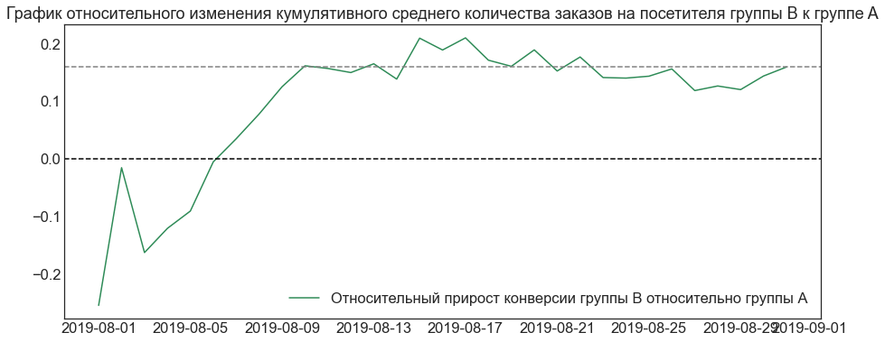

```python
plt.figure(figsize=(15, 6))
sns.set(font_scale=1.5)
plt.style.use('seaborn-white')

plt.plot(mergedCumulativeConversions['date'],
         mergedCumulativeConversions['conversionB']/mergedCumulativeConversions['conversionA']-1,
         label='Относительный прирост конверсии группы В относительно группы А', color='seagreen')
plt.legend()

plt.axhline(y=0, color='black', linestyle='--')
plt.axhline(y=0.16, color='grey', linestyle='--')
plt.title('График относительного изменения кумулятивного среднего количества заказов на посетителя группы B к группе A')

plt.show();
```

- в начале теста группа В проигрывала группе А. Но затем, во время второго скачка роста, группа В значительно оторвалась от группы А. Затем конверсия снижалась, но ненамного. В целом группа В уверенно показывает результаты лучше группы А.

### Точечный график количества заказов по пользователям. Выводы и предположения.

```python
ordersByUsers = (orders.groupby('visitorId', as_index=False)
                        .agg({'transactionId':'nunique'}))
ordersByUsers.columns = ['userId','orders']
ordersByUsers
```

|  | userId | orders |
| --- | --- | --- |
| 0 | 5114589 | 1 |
| 1 | 6958315 | 1 |
| 2 | 11685486 | 1 |
| 3 | 39475350 | 1 |
| 4 | 47206413 | 1 |
| ... | ... | ... |
| 968 | 4259830713 | 1 |
| 969 | 4278982564 | 1 |
| 970 | 4279090005 | 1 |
| 971 | 4281247801 | 1 |
| 972 | 4283872382 | 1 |

973 rows × 2 columns

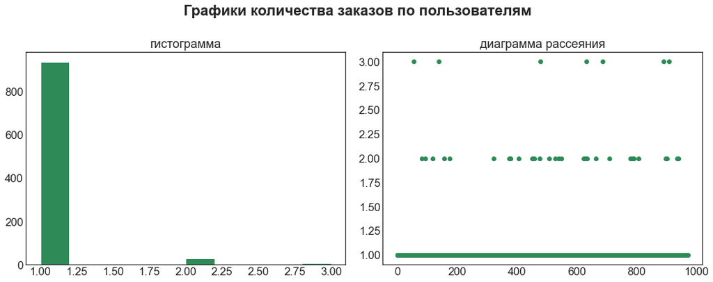

```python
plt.figure(figsize=(15, 6))
sns.set(font_scale=1.5)
plt.style.use('seaborn-white')
plt.suptitle('Графики количества заказов по пользователям', fontweight='bold')

ax1 = plt.subplot(1, 2, 1)
plt.hist(ordersByUsers['orders'], color='seagreen')
plt.title('гистограмма')
plt.xlabel('')
plt.ylabel('')

ax2 = plt.subplot(1, 2, 2)
x_values = pd.Series(range(0, len(ordersByUsers)))
plt.scatter(x_values, ordersByUsers['orders'], color='seagreen')
plt.title('диаграмма рассеяния')
plt.xlabel('')
plt.ylabel('')

plt.tight_layout()
plt.show();
```

- большинство пользователей совершает один заказ, но при этом достаточно много людей делает заказ дважды. Большее количество заказов встречается редко.

### 95-й и 99-й перцентили количества заказов на пользователя. Установление границы для определения аномальных пользователей.

```python
np.percentile(ordersByUsers['orders'], [95, 99])
```

```
array([1., 2.])
```

Принято отсеивать от 1 до 5% наблюдений с крайними значениями. В нашем случае это больше 1 и больше 2-х заказов на пользователя. Возьмём за границу нормы 99-й перцентиль.

### Точечный график стоимостей заказов. Выводы и предположения.

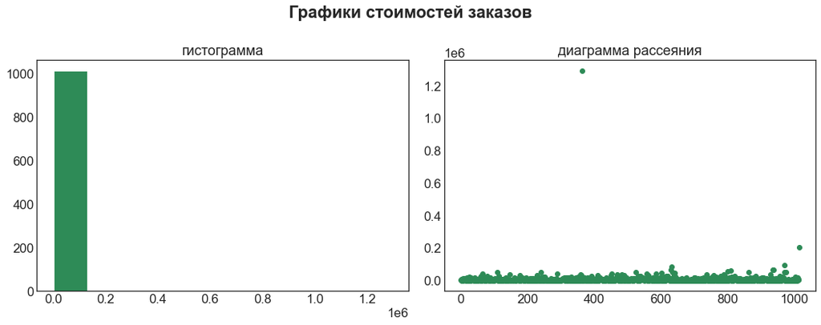

```python
plt.figure(figsize=(15, 6))
sns.set(font_scale=1.5)
plt.style.use('seaborn-white')
plt.suptitle('Графики стоимостей заказов', fontweight='bold')

ax1 = plt.subplot(1, 2, 1)
plt.hist(orders['revenue'], color='seagreen')
plt.title('гистограмма')
plt.xlabel('')
plt.ylabel('')

ax2 = plt.subplot(1, 2, 2)
x_values = pd.Series(range(0, len(orders['revenue'])))
plt.scatter(x_values, orders['revenue'], color='seagreen')
plt.title('диаграмма рассеяния')
plt.xlabel('')
plt.ylabel('')

plt.tight_layout()
plt.show();
```

- вот мы и увидели аномалии: у нас в данных есть заказ на сумму более 1 млн 200 тыс и ещё один заказ со стоимостью около 200 тысяч. Они явно выделяются на общем фоне - остальные заказы в основном приносят доход до 100 тыс

### 95-й и 99-й перцентили стоимости заказов. Выбор границы для определения аномальных заказов.

```python
np.percentile(orders['revenue'], [95, 99])
```

```
array([26785., 53904.])
```

5% заказов имеют стоимость свыше 26 тысяч и 1% заказов имеет стоимость более 53 тысяч. Возьмём за границу "нормы" 99-й перцентиль.

### Статистическая значимость различий в среднем количестве заказов на посетителя между группами по «сырым» данным. Выводы и предположения.

Подготовим данные:

```python
visitorsADaily = visitors[visitors['group'] == 'A'][['date', 'visitors']]
visitorsADaily.columns = ['date', 'visitorsPerDateA']

visitorsACummulative = visitorsADaily.apply(
    lambda x: visitorsADaily[visitorsADaily['date'] <= x['date']].agg(
        {'date': 'max', 'visitorsPerDateA': 'sum'}
    ),
    axis=1,
)
visitorsACummulative.columns = ['date', 'visitorsCummulativeA']

visitorsBDaily = visitors[visitors['group'] == 'B'][['date', 'visitors']]
visitorsBDaily.columns = ['date', 'visitorsPerDateB']

visitorsBCummulative = visitorsBDaily.apply(
    lambda x: visitorsBDaily[visitorsBDaily['date'] <= x['date']].agg(
        {'date': 'max', 'visitorsPerDateB': 'sum'}
    ),
    axis=1,
)
visitorsBCummulative.columns = ['date', 'visitorsCummulativeB']

ordersADaily = (
    orders[orders['group'] == 'A'][['date', 'transactionId', 'visitorId', 'revenue']]
    .groupby('date', as_index=False)
    .agg({'transactionId': pd.Series.nunique, 'revenue': 'sum'})
)
ordersADaily.columns = ['date', 'ordersPerDateA', 'revenuePerDateA']

ordersACummulative = ordersADaily.apply(
    lambda x: ordersADaily[ordersADaily['date'] <= x['date']].agg(
        {'date': 'max', 'ordersPerDateA': 'sum', 'revenuePerDateA': 'sum'}
    ),
    axis=1,
).sort_values(by=['date'])
ordersACummulative.columns = [
    'date',
    'ordersCummulativeA',
    'revenueCummulativeA',
]

ordersBDaily = (
    orders[orders['group'] == 'B'][['date', 'transactionId', 'visitorId', 'revenue']]
    .groupby('date', as_index=False)
    .agg({'transactionId': pd.Series.nunique, 'revenue': 'sum'})
)
ordersBDaily.columns = ['date', 'ordersPerDateB', 'revenuePerDateB']

ordersBCummulative = ordersBDaily.apply(
    lambda x: ordersBDaily[ordersBDaily['date'] <= x['date']].agg(
        {'date': 'max', 'ordersPerDateB': 'sum', 'revenuePerDateB': 'sum'}
    ),
    axis=1,
).sort_values(by=['date'])
ordersBCummulative.columns = [
    'date',
    'ordersCummulativeB',
    'revenueCummulativeB',
]

data = (
    ordersADaily.merge(
        ordersBDaily, left_on='date', right_on='date', how='left'
    )
    .merge(ordersACummulative, left_on='date', right_on='date', how='left')
    .merge(ordersBCummulative, left_on='date', right_on='date', how='left')
    .merge(visitorsADaily, left_on='date', right_on='date', how='left')
    .merge(visitorsBDaily, left_on='date', right_on='date', how='left')
    .merge(visitorsACummulative, left_on='date', right_on='date', how='left')
    .merge(visitorsBCummulative, left_on='date', right_on='date', how='left')
)

data.head(5)
```

|  | date | ordersPerDateA | revenuePerDateA | ordersPerDateB | revenuePerDateB | ordersCummulativeA | revenueCummulativeA | ordersCummulativeB | revenueCummulativeB | visitorsPerDateA | visitorsPerDateB | visitorsCummulativeA | visitorsCummulativeB |
| --- | --- | --- | --- | --- | --- | --- | --- | --- | --- | --- | --- | --- | --- |
| 0 | 2019-08-01 | 23 | 142779 | 17 | 59758 | 23 | 142779 | 17 | 59758 | 719 | 713 | 719 | 713 |
| 1 | 2019-08-02 | 19 | 91602 | 23 | 162043 | 42 | 234381 | 40 | 221801 | 619 | 581 | 1338 | 1294 |
| 2 | 2019-08-03 | 24 | 112473 | 14 | 67049 | 66 | 346854 | 54 | 288850 | 507 | 509 | 1845 | 1803 |
| 3 | 2019-08-04 | 11 | 41176 | 14 | 96890 | 77 | 388030 | 68 | 385740 | 717 | 770 | 2562 | 2573 |
| 4 | 2019-08-05 | 22 | 86383 | 21 | 89908 | 99 | 474413 | 89 | 475648 | 756 | 707 | 3318 | 3280 |

Создадим переменные для обеих групп теста, где для пользователей, которые что-либо купили, укажем число совершённых заказов:

```python
ordersByUsersA = (orders[orders['group']=='A']
                    .groupby('visitorId', as_index=False)
                    .agg({'transactionId':pd.Series.nunique}))
ordersByUsersA.columns=['userId','orders']

ordersByUsersB = (orders[orders['group']=='B']
                    .groupby('visitorId', as_index=False)
                    .agg({'transactionId':pd.Series.nunique}))
ordersByUsersB.columns=['userId','orders']

ordersByUsersA
```

|  | userId | orders |
| --- | --- | --- |
| 0 | 11685486 | 1 |
| 1 | 54447517 | 1 |
| 2 | 66685450 | 1 |
| 3 | 78758296 | 1 |
| 4 | 85103373 | 1 |
| ... | ... | ... |
| 440 | 4227830084 | 1 |
| 441 | 4237561104 | 1 |
| 442 | 4243832526 | 1 |
| 443 | 4259830713 | 1 |
| 444 | 4278982564 | 1 |

445 rows × 2 columns

Подготовим выборки к проверке критерием Манна-Уитни:

```python
sampleA = pd.concat([ordersByUsersA['orders'],
                     pd.Series(0, index=np.arange(data['visitorsPerDateA'].sum() - len(ordersByUsersA['orders'])),
                               name='orders')], axis=0)

sampleB = pd.concat([ordersByUsersB['orders'],
                     pd.Series(0, index=np.arange(data['visitorsPerDateB'].sum() - len(ordersByUsersB['orders'])),
                               name='orders')], axis=0)

sampleA
```

```
0        1
1        1
2        1
3        1
4        1
        ..
18286    0
18287    0
18288    0
18289    0
18290    0
Name: orders, Length: 18736, dtype: int64
```

Гипотезы:

- H0 - различий в среднем количестве заказов между группами А и В нет
- H1 - различия в среднем количестве заказов между группами А и В есть

Для выявления статистической значимости применим критерий Манна-Уитни и округлим p-value до 3-х знаков после запятой:

```python
alpha = 0.05 #критический уровень статистической значимости

p_value = st.mannwhitneyu(sampleA, sampleB)[1]
print(f'p-значение: {"{0:.3f}".format(p_value)}')

if p_value < alpha:
    print('Отвергаем нулевую гипотезу: между группами есть статистически значимое различие')
else:
    print('Не получилось отвергнуть нулевую гипотезу: между группами нет статистически значимого различия')
```

```
p-значение: 0.011
Отвергаем нулевую гипотезу: между группами есть статистически значимое различие
```

Надём дополнительно относительный прирост среднего числа заказов группы В:

```python
print("{0:.3f}".format(sampleB.mean() / sampleA.mean() - 1))
```

```
0.160
```

Относительный прирост среднего группы В составляет 16%. Этот прирост небольшой, но статистически значимый.

### Статистическая значимость различий в среднем чеке заказа между группами по «сырым» данным. Выводы и предположения.

Гипотезы:

- H0 - различий в среднем чеке между группами А и В нет
- H1 - различия в среднем чеке между группами А и В есть

```python
alpha = 0.05 #критический уровень статистической значимости

p_value = st.mannwhitneyu(orders[orders["group"]=="A"]["revenue"],orders[orders["group"]=="B"]["revenue"])[1]
print(f'p-значение: {"{0:.3f}".format(p_value)}')

if p_value < alpha:
    print('Отвергаем нулевую гипотезу: между группами есть статистически значимое различие')
else:
    print('Не получилось отвергнуть нулевую гипотезу: между группами нет статистически значимого различия')
```

```
p-значение: 0.829
Не получилось отвергнуть нулевую гипотезу: между группами нет статистически значимого различия
```

Посмотрим на отноистельный прирост группы В:

```python
print("{0:.3f}".format(orders[orders['group']=='B']['revenue'].mean() /
                                      orders[orders['group']=='A']['revenue'].mean() - 1))
```

```
0.287
```

Мы наблюдаем относительный прирост группы В - это почти 29%. Однако, согласно результату теста, он не является статистически значимым.

### Статистическая значимость различий в среднем количестве заказов на посетителя между группами по «очищенным» данным. Выводы и предположения.

Ранее мы определили для себя условную границу нормы: и в случае с количеством заказов, и в случае с чеками это 99-й перцентиль.

```python
orders_lim = np.percentile(ordersByUsersA['orders'], 99)
usersWithManyOrders = pd.concat(
    [
        ordersByUsersA[ordersByUsersA['orders'] > orders_lim]['userId'],
        ordersByUsersB[ordersByUsersB['orders'] > orders_lim]['userId'],
    ],
    axis=0,
)

revenue_lim = np.percentile(orders['revenue'], 99)
usersWithExpensiveOrders = orders[orders['revenue'] > revenue_lim]['visitorId']

abnormalUsers = (
    pd.concat([usersWithManyOrders, usersWithExpensiveOrders], axis=0)
    .drop_duplicates()
    .sort_values()
)
```

Посмотрим, сколько пользователей мы отсеяли:

```python
print(abnormalUsers.shape[0])
```

```
16
```

Подготавливаем выборки:

```python
sampleAFiltered = pd.concat([ordersByUsersA[np.logical_not(ordersByUsersA['userId'].isin(abnormalUsers))]['orders'],
        pd.Series(0, index=np.arange(data['visitorsPerDateA'].sum() - len(ordersByUsersA['orders'])), name='orders')],
        axis=0)

sampleBFiltered = pd.concat([ordersByUsersB[np.logical_not(ordersByUsersB['userId'].isin(abnormalUsers))]['orders'],
        pd.Series(0, index=np.arange(data['visitorsPerDateB'].sum() - len(ordersByUsersB['orders'])),name='orders')],
        axis=0)
```

Применим статистический критерий Манна-Уитни к полученным выборкам:

```python
alpha = 0.05 #критический уровень статистической значимости

p_value = st.mannwhitneyu(sampleAFiltered, sampleBFiltered)[1]
print(f'p-значение: {"{0:.3f}".format(p_value)}')

if p_value < alpha:
    print('Отвергаем нулевую гипотезу: между группами есть статистически значимое различие')
else:
    print('Не получилось отвергнуть нулевую гипотезу: между группами нет статистически значимого различия')
```

```
p-значение: 0.007
Отвергаем нулевую гипотезу: между группами есть статистически значимое различие
```

В "сырых" данных p-value составлял 0.011, теперь в "очищенном" варианте p-value равняется 0.007, выводы от этого не изменились, нулевая гипотеза снова отвергнута.

Посмотрим на относительный прирост среднего группы В в "очищенном" варианте:

```python
print('{0:.3f}'.format(sampleBFiltered.mean()/sampleAFiltered.mean()-1))
```

```
0.189
```

Относительный прирост в "сырых" данных составлял 16%, в "очищенных" данных даже больше: 18.9%. В данном случае относительный прирост согласуется с результатами статистического теста.

### Статистическая значимость различий в среднем чеке заказа между группами по «очищенным» данным. Выводы и предположения.

```python
alpha = 0.05 #критический уровень статистической значимости

p_value = st.mannwhitneyu(orders[np.logical_and(orders["group"] == "A",
                                                np.logical_not(orders["visitorId"].isin(abnormalUsers)))]["revenue"],
                          orders[np.logical_and(orders["group"] == "B",
                                                np.logical_not(orders["visitorId"].isin(abnormalUsers)))]["revenue"])[1]
print(f'p-значение: {"{0:.3f}".format(p_value)}')

if p_value < alpha:
    print('Отвергаем нулевую гипотезу: между группами есть статистически значимое различие')
else:
    print('Не получилось отвергнуть нулевую гипотезу: между группами нет статистически значимого различия')
```

```
p-значение: 0.788
Не получилось отвергнуть нулевую гипотезу: между группами нет статистически значимого различия
```

В "сырых" данных p-значение было 0.829, теперь оно другое, но выводы прежние - между группами нет статистически значимого различия.

Относительный прирост среднего группы В:

```python
print("{0:.3f}".format(orders[np.logical_and(orders['group'] == 'B',
                np.logical_not(orders['visitorId'].isin(abnormalUsers)))]['revenue'].mean() /
                orders[np.logical_and(orders['group'] == 'A',
                np.logical_not(orders['visitorId'].isin(abnormalUsers)))]['revenue'].mean() - 1))
```

```
-0.032
```

Относительный прирост в "сырых" данных был 0.287, а теперь он даже отрицательный -0.032. Здесь мы уже видим значительное отличие между "сырыми" и "отфильтрованными" данными. Это следствие влияния аномалий. По результатам теста, любой прирост или проигрыш не является статистически значимым.

### Решение по результатам теста

Для принятия и обоснования решения пройдёмся ещё раз по полученным результатам по шагам:

1. Среднее количество заказов: статистически значимое отличие между группами есть и по сырым, и по очищенным данным. Группа В показывает относительный прирост 16% по сырым и 18.9% по очищенным данным
2. Средний чек: статистически значимого отличия между группами нет ни по сырым, ни очищенным данным.
3. График различия среднего количества заказов между группами (раздел 5.6) сообщает, что результаты группы B лучше группы A
4. График различия среднего чека (раздел 5.4) колеблется, эти колебания помогли обнаружить аномалии. Однозначный вывод по этому графику сделать нельзя, но в целом результаты группы B лучше результатов группы А (в основном выше нуля)

На основе этих фактов можно принять решение:

Следует остановить тест, зафиксировать победу группы В. Средние чеки не изменились, но в группе В есть статистически значимое отличие в количестве заказов. Увеличение количества заказов повлияет и на выручку. Значит, мы можем признать тест успешным.

## Выводы

**Приоритизация гипотез**

Список наиболее приоритетных гипотез, составленный при помощи фреймворков:

**ICE**:

1. Запустить акцию, дающую скидку на товар в день рождения
2. Добавить два новых канала привлечения трафика, что позволит привлекать на 30% больше пользователей
3. Добавить форму подписки на все основные страницы, чтобы собрать базу клиентов для email-рассылок

**RICE**:

1. Добавить форму подписки на все основные страницы, чтобы собрать базу клиентов для email-рассылок
2. Добавить блоки рекомендаций товаров на сайт интернет магазина, чтобы повысить конверсию и средний чек заказа
3. Добавить два новых канала привлечения трафика, что позволит привлекать на 30% больше пользователей

**Почему происходят изменения в приоритизации**:

- при применении фреймворка RICE вместо ICE меняется приоритизация гипотез. Это происходит из-за добавления параметра Reach, то есть охвата пользователей.
- при этом гипотезы, которые в ICE набрали много баллов, при переходе в RICE меняются между собой местами, но остаются на лидирующих позициях. А гипотезы, имеющие низкие баллы в ICE, даже при сильном параметре Reach, не смогли выбраться в топ во фреймворке RICE.

**A/B-тест**

На этапе предобработки были выявлены 58 пользователей, которые попали в обе группы теста. Было принято решение не включать данные об их покупках в анализ результатов теста.

- **Среднее количество заказов**: статистически значимое отличие между группами есть и по сырым, и по очищенным данным. Группа В показывает относительный прирост 16% по сырым и 18.9% по очищенным данным
- **Средний чек**: статистически значимого отличия между группами нет ни по сырым, ни очищенным данным.
- **График различия среднего количества заказов** между группами (раздел 5.6) сообщает, что результаты группы B лучше группы A
- **График различия среднего чека** (раздел 5.4) колеблется, эти колебания помогли обнаружить аномалии. Однозначный вывод по этому графику сделать нельзя, но в целом результаты группы B лучше результатов группы А (в основном выше нуля)

На основе этих фактов можно принять решение: **следует остановить тест, зафиксировать победу группы В**. Средние чеки не изменились, но в группе В есть статистически значимое отличие в количестве заказов. Увеличение количества заказов повлияет и на выручку. Значит, мы можем признать тест успешным.

Исследование выполнила: аналитик данных Малахова Наталья

Мой телеграм-канал: [Дневник аналитика](https://t.me/diary_musician_analyst)

Портфолио: [GitHub](https://github.com/Malakhova-Natalya)

Спасибо за внимание!